# R Basics

## Matrices

Matrices are two dimensional vectors. Lets define a matrix.

```r
mat=matrix(data=c(9,2,3,4,5,6, ncol=3))
```

1. argument data specifies which numbers should be in the matrix
2. ncol or nrow specify the number of columns or rows
3. elements of a matrix can be addressed: [row,column]
4. to select whole row leave the spot for column empty mat [2,]
5. functions also work with matrices mean(mat)

## Simple graphics

Plot:

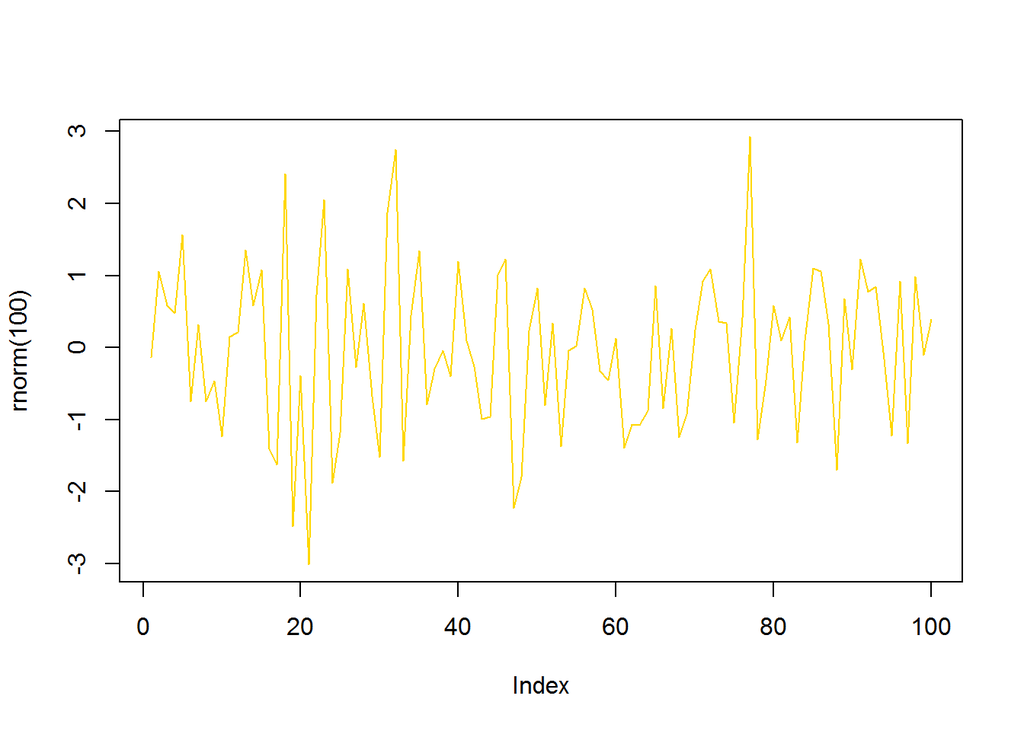

```r
plot(rnorm(100), type="l", col="gold")
```

## Summaries

Create data frame:

```r
x1<-rnorm(100)
x2<-rnorm(100)
x3<-rnorm(100)
t<-data.frame(a=x1, b=x1+x2, c=x1+x2+x3)
```

Summary:

```r
summary(t)
```

```
##        a                 b                  c
##  Min.   :-1.9832   Min.   :-3.98109   Min.   :-4.16553
##  1st Qu.:-0.4789   1st Qu.:-0.83278   1st Qu.:-0.89348
##  Median : 0.2039   Median : 0.06475   Median : 0.08176
##  Mean   : 0.2195   Mean   : 0.28339   Mean   : 0.11914
##  3rd Qu.: 0.8735   3rd Qu.: 1.32978   3rd Qu.: 1.22236
##  Max.   : 3.2310   Max.   : 4.85515   Max.   : 4.79648
```

```r
str(t) # shows data types
```

```
## 'data.frame':    100 obs. of  3 variables:
##  $ a: num  -1.255 0.644 -0.75 -0.522 -0.671 ...
##  $ b: num  -1.761 0.628 -0.454 -1.087 -0.868 ...
##  $ c: num  -3.704 1.866 -1.226 -1.742 -0.153 ...
```

```r
head(t) # shows first few rows
```

```
##            a          b           c
## 1 -1.2551503 -1.7611275 -3.70440639
## 2  0.6441284  0.6284669  1.86623330
## 3 -0.7500326 -0.4540989 -1.22648114
## 4 -0.5217682 -1.0870068 -1.74155024
## 5 -0.6709569 -0.8677562 -0.15315482
## 6 -0.2949309 -0.3654803  0.08627225
```

```r
tail(t) # shows last few rows
```

```
##              a          b         c
## 95   3.2310036  4.8551465  4.414056
## 96   1.2527485 -0.2221403 -1.471211
## 97  -0.4362752 -1.0116807  0.173032
## 98  -0.8717327 -0.6523400 -2.384407
## 99  -0.9134172 -2.5510751 -4.100746
## 100 -1.7440092 -3.1196923 -4.165526
```

[output not shown]

[output not shown]

[output not shown]